# California Alloscoring - Summary

Emily Tyszka

2026-01-22

# Background

## Forecast Scoring

In the development of these forecasts, teams utilize a wide range of inputs and methodologies, and as a result models may vary widely in their forecast accuracy. Furthermore, model performance may be context-specific - models that perform well in one setting or time period may produce inaccurate predictions and decisions in another, due to differences in the qualities of the population of interest, variation in data accuracy/timeliness, changes in disease dynamics, unaccounted-for variables, or other factors. For this reason, the question of what is the “best model” for a time or context requires standardized methods of scoring and assessment. In response to this need, a number of methods of model assessment have been developed, which quantitatively “score” forecasts on their success predicting outcomes.

## Existing scoring methods

Currently, a number of scoring methods exist across the infectious disease forecasting space. All methods evaluate a given forecast against the *truth* (the final outcome, of which the forecasters had no knowledge at time of prediction) for a given target (count at a date and time horizon) and then aggregate those into a total score for the model as a whole over the period tested. They are detailed briefly below:

- **Mean Absolute Error (MAE)**: Mean absolute deviation of the prediction from the true value. On the same scale as the prediction. This measure uses point estimates only.
- **Root Mean Square Error (RMSE)**: Average deviation of the prediction from the true value, calculated by taking the square root of the average squared residuals. On the same scale as the prediction. This measure uses point estimates only.
- **Logarithmic Score (LS):** The log of the probability assigned to the observed outcome by the forecast. The higher, the better, since it means that the forecast marked the outcome more “likely”
- **Continuous Ranked Probability Score (CRPS):** For a prediction is given as a distribution, this score compares the CDF of the predicted values with the step-function CDF of the true value (where cumulative probability is 0 at values less than the true value, 1 at values above). The 2 curves are overlaid and the area between them is measured as the squared difference between the forecasted and observed CDFs. A lower CRPS is indicative of better model performance, as it differs less than the stepwise function that is being used as a stand-in for the truth.
- **Weighted Interval Score (WIS)**: An interval score expresses the width of the interval, with larger intervals receiving higher scores (higher scores indicate less accuracy) and incorporates a penalty if the interval does not cover the eventual observation, which increases the further away the interval is from the observed value. The WIS weighted sum of interval scores at different probability levels, based on their PI width.
  - **Mean WIS**

## Allocation Score

When selecting a forecast or forecasts to make predictions of a given infectious disease outcome, the above methods can serve as quantitative measures of forecast accuracy, allowing for easy comparison between model performances. All of the existing methods described above, however, evaluate the forecasts entirely on whether how correct a forecast’s predictions can be considered to be, which may or may not translate to well-informed decision-making when the model is applied in practice. In short, it is an issue of accuracy vs. utility.

The allocation score, introduced by [Gerding et al. in 2024](https://academic.oup.com/jrsssa/article/188/4/1299/7927906), scores forecasts instead on their success in allocating limited medical resources across multiple locations. For a given forecast date and time horizon, an forecast is evaluated across all locations together, penalizing any instance where resources are underallocated to a location (relative to the best possible allocation).

### Overview:

In its simplest form, this scoring framework:

1. Identifies a set of limited resources* of count K, which will be distributed across the locations based on their forecasts.
2. Compiles a set of disease burden forecasts for multiple locations (ex. all counties in a state) and distributes the limited resources according to the forecast’s prediction of disease burden (ie. predicted need) in those locations.
3. Determines the true need across all locations from the true counts (finalized after the forecasted date has passed)
4. Generates an ideal “oracle” distribution that would be made by a decision-maker with knowledge of the true need. If there are fewer resources than total need, this may underallocate resources, but this is considered to be unavoidable.
5. Calculates total avoidable unmet need:
   1. Total unmet need: Forecasts that distribute fewer units of resource than required in a given location leave unmet need. This is summed across all locations. Where more resources than are needed are allocated, this number is 0.
   2. Total unavoidable unmet need: In cases of resource constraints, it is not possible to distribute resources such that all locations meet their needs. If the oracle distribution requires more units of resource than exist in the distribution problem, the difference is defined as unavoidable unmet need. This is summed across all locations.
   3. Total avoidable unmet need = total unmet need - total unavoidable unmet need
6. This count of total avoidable unmet need is the **allocation score (AS)**.

###### *Note: the resources in question remain theoretical, but are considered to be available for distribution to the locations of interest. For example, ventilators, PPE, or mobile staffing such as travel nurses may all be “sent” to a location that predicts higher resource need. Hospital beds, while in some ways able to be distributed (as through the setup of field hospitals) are less mobile and perhaps less suited to this particular thought experiment. Regardless, the actual resource does not matter, so long as it may be distributed across locations based on a set of forecasts, its need is expressed by the disease burden forecasts of interest, and it can be “wasted” if incorrectly distributed.

### Example:

Below, we see an simplified illustration of an allocation scoring scenario. In this scenario, 20,000 units of resources are to be distributed between 4 counties of different populations at a set point in time. 3 allocation methods are being scored: an allocation proportional to county population and two allocations according to the predictions of forecasts. On the far right, the oracle distribution is shown in grey - note that it exhibits 800 units of unavoidable unmet need.

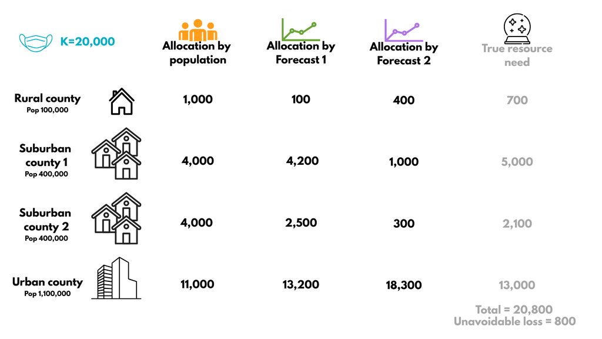

The 3 allocations are scored by first determining the loss for each location and model (ie. tallying all unmet need - where the allocation is less than the true resource need). Overallocation is not penalized.

For each allocation, this is summed, then unavoidable unmet need is subtracted from the value to give the alloscore. (For example, allocation by population had a total 3,000 units of need - subtracting 800 gives the alloscore of 2,200.)

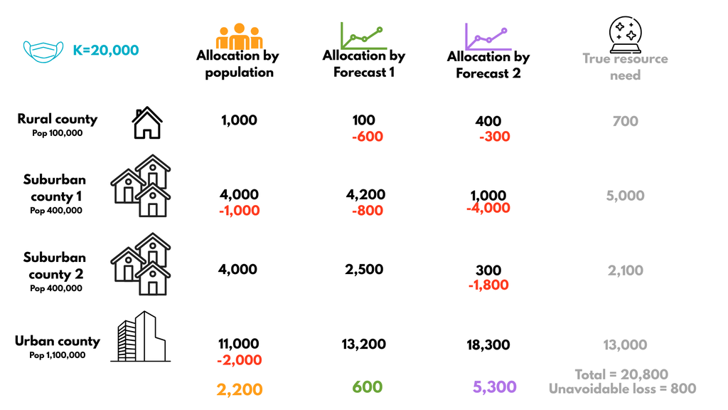

With this method, we can treat the allocation by population as a control method and judge our two forecasts with regards to how well they inform resource distribution decisions in the scenario of interest, compared to an allocation that ignores predicted disease burden - in this example, Forecast 1 scored better, while Forecast 2 scored worse.

### AS for Probabilistic Forecasts:

Expanding upon this method for use with probabilistic forecasts, where predictions are expressed in terms of quantiles of a probability distribution, the basic allocation score method is expanded by:

- Generating a *loss function*, which expresses the sum of contributions from unmet need in each location, for a given allocation.
- Incorporating the probability distributions of each forecast, find the expected value of the loss function across all locations for the allocation of interest.
- Selecting the allocation which minimizes the value of the loss function.

### Some additional notes:

Additional considerations for the allocation score:

- “At its core, the AS measures whether the forecast accurately captures the relative magnitudes of resource need across different locations, which is precisely the information that is needed to allocate resources to those locations subject to a fixed resource constraint.” - Gerding et al.
- The numerical values of the allocation score are dependent upon the resource constraint established when selecting K. All else being equal, with a selected K that is closer to true need, we can expect a higher AS because allocation decisions matter more: not only is there the potential for unmet need, but it is avoidable with better-informed decision-making.
  - As a result of this, it should be noted that raw AS values *between* experiments are not comparable. Two compare the raw AS values of two forecasts, they should be subjected to the same experiment.
  - As an additional extension to the AS, the calculation of **Integrated Allocation Score (IAS)** addresses uncertainty with regards to resource levels. This score is generated by determining AS across a grid of discrete possible K values, weighed by their probabilities.

# Project Justification and Goals

# Experimental Outline

1. **Select a subset of models that submitted forecasts on the weeks of 11/21/2020 and 12/25/2021.** Additional criteria include:
   1. Forecasts must submit predictions for all CA counties.
   2. Predictions must include at least 5 quantiles
   3. Forecasts must include predictions for the 1 week, 2 week, 3 week, and 4 week time horizons
      1. 11/21/2020: target dates of 2020-11-28, 2020-12-05, 2020-12-12, and 2020-12-19
      2. 12/25/2021: target dates of 2022-01-01, 2022-01-08, 2022-01-15, and 2022-01-22
   4. As a control, a per capita allocation will be used: *allocation based on county census population*
2. **Run the allocation score for the selected forecasts on the 2 dates:**
   1. For each time period of interest, select a resource count. These counts should make loss inevitable, so that allocation scores are meaningful (with too many resources, AS values could all be 0)
   2. For each model, week, and horizon, calculate the allocation score across all locations.
3. **Compare allocation score results to mWIS (and other?) scoring methods:**
   1. Visualize score for each model by week for the selected horizons (like plot Nick quickly made)
      1. Put next to the same for WIS
   2. Visualize relative ranks over time (is there a good non spaghetti way to do this?)
      1. And is there any way to compile this? Metrics average ranking, etc.
   3. Visualize loss (it’s in the manuscript)
   4. Select 3 top models: visualize (time series graphs in manuscript)
4. **[Further rabbitholes]**
   1. Regional evaluation as done in the CDPH paper
   2. Experiment with what model missingness does

# Time Period of Interest

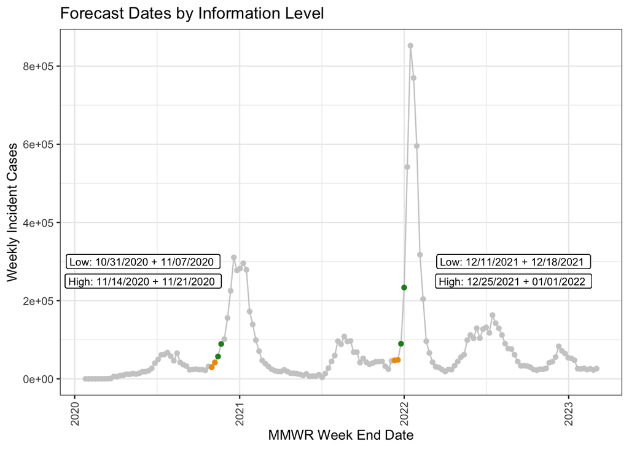

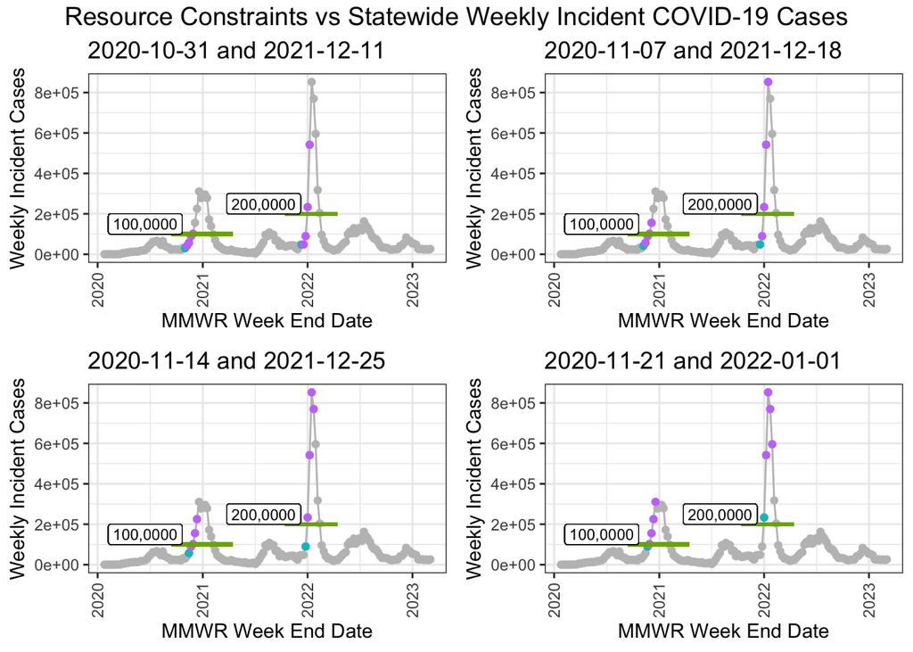

# Data Sources and Selection

## COVID-19 Forecast Data

## Model Selection

We will therefore visualize, by forecast date + quantile, how many predictions each model submitted for each horizon.

### October 31st, 2020

#### 50%

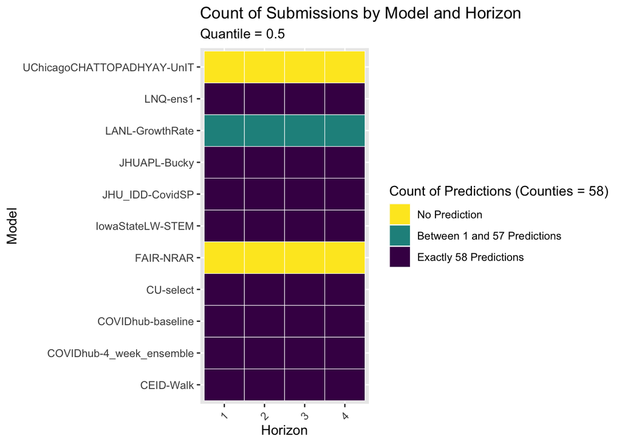

#### 25%

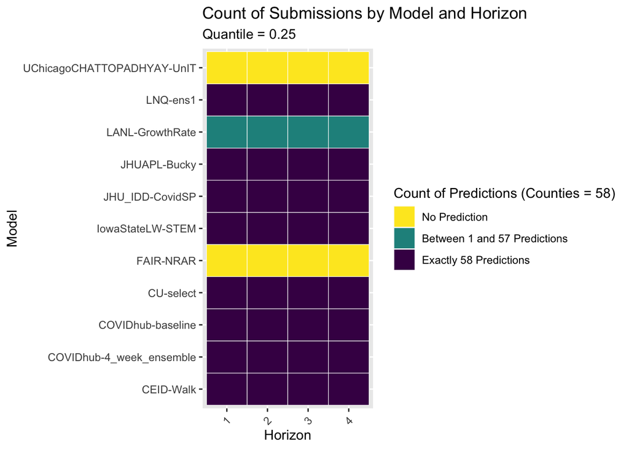

#### 10%

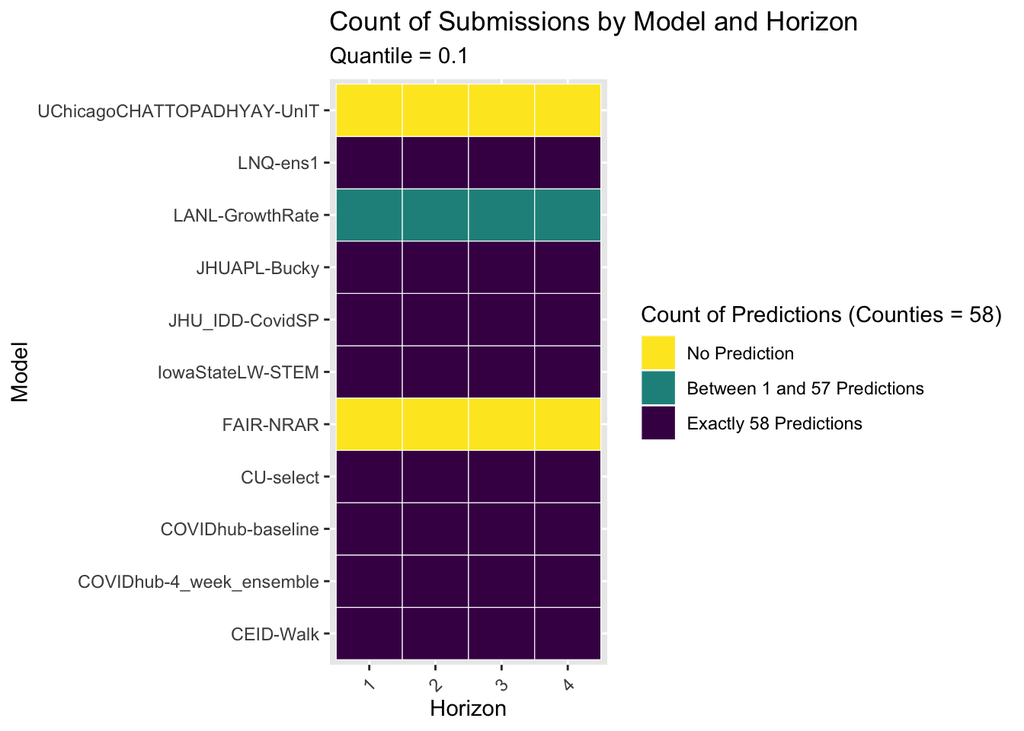

#### 2.5%

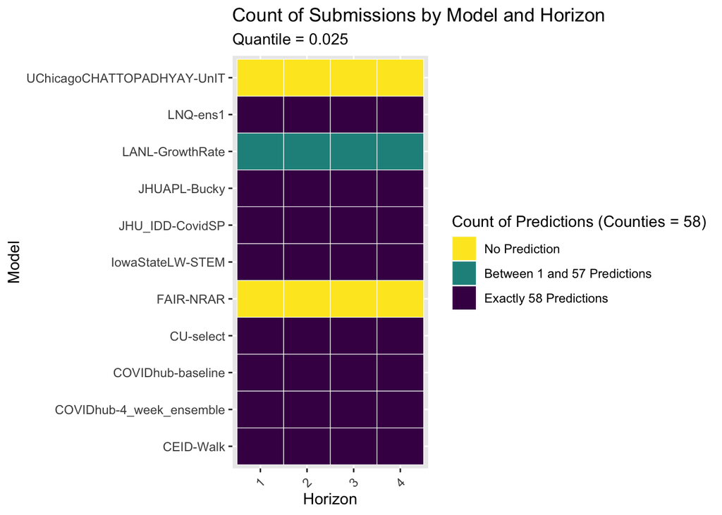

### November 7th, 2020

#### 50%

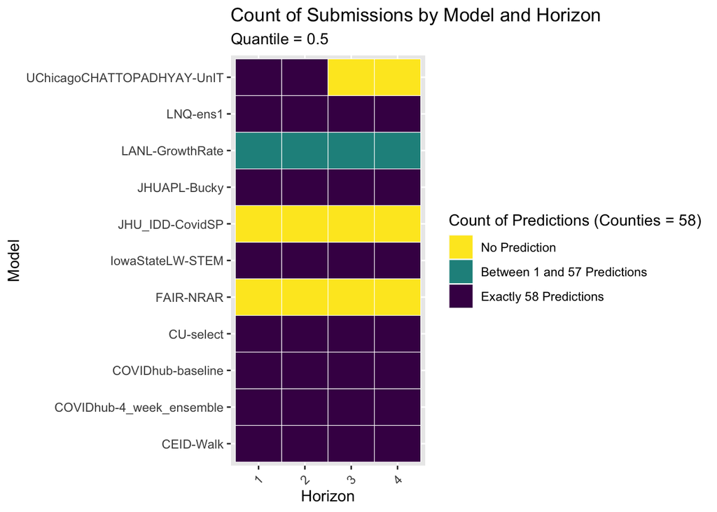

#### 25%

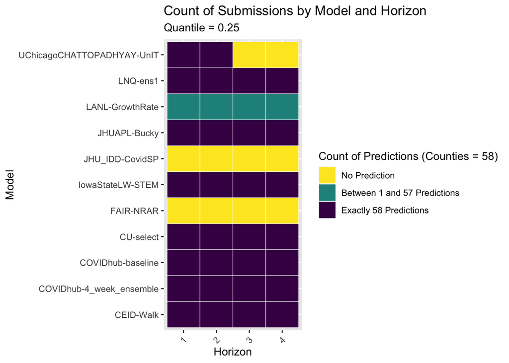

#### 10%

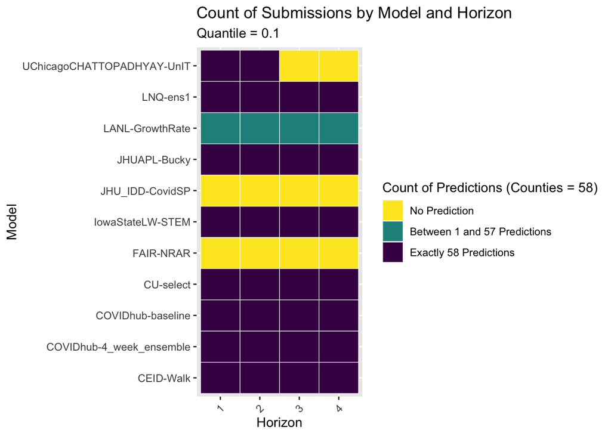

#### 2.5%

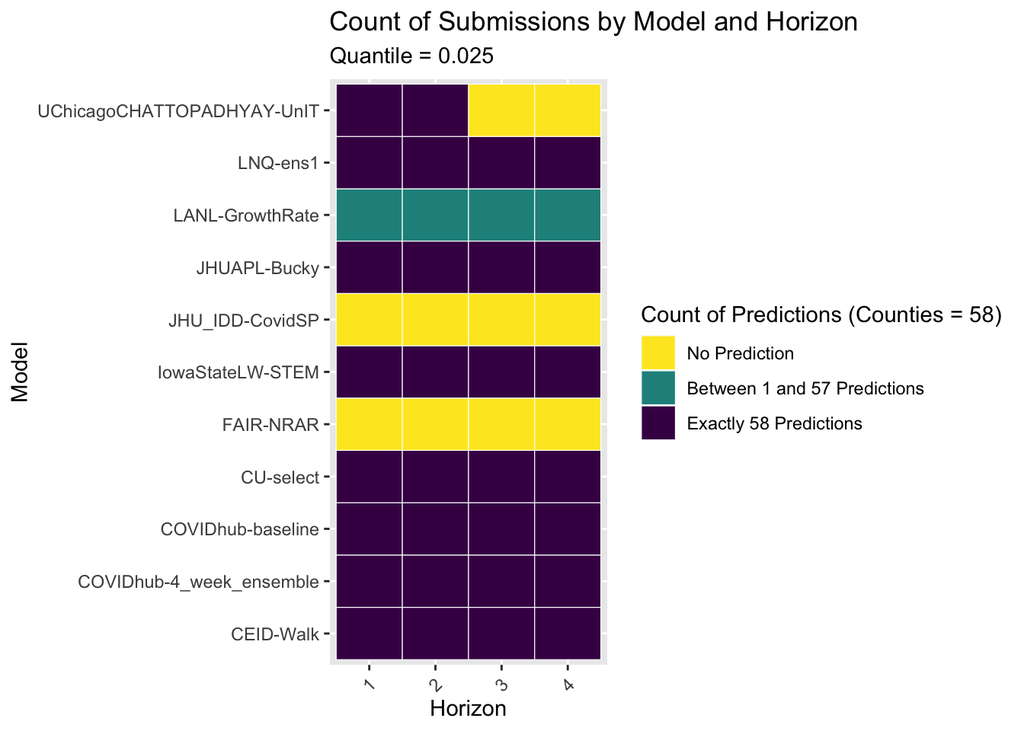

### November 14th, 2020

#### 50%

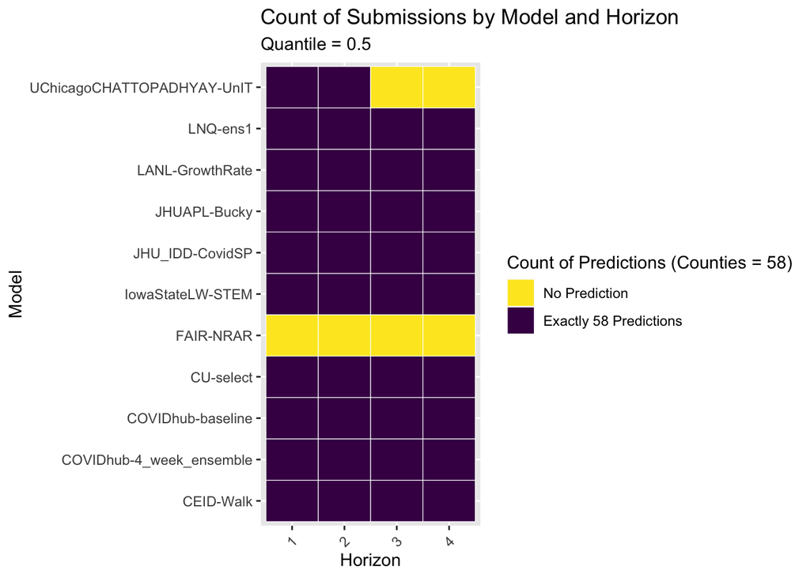

#### 25%

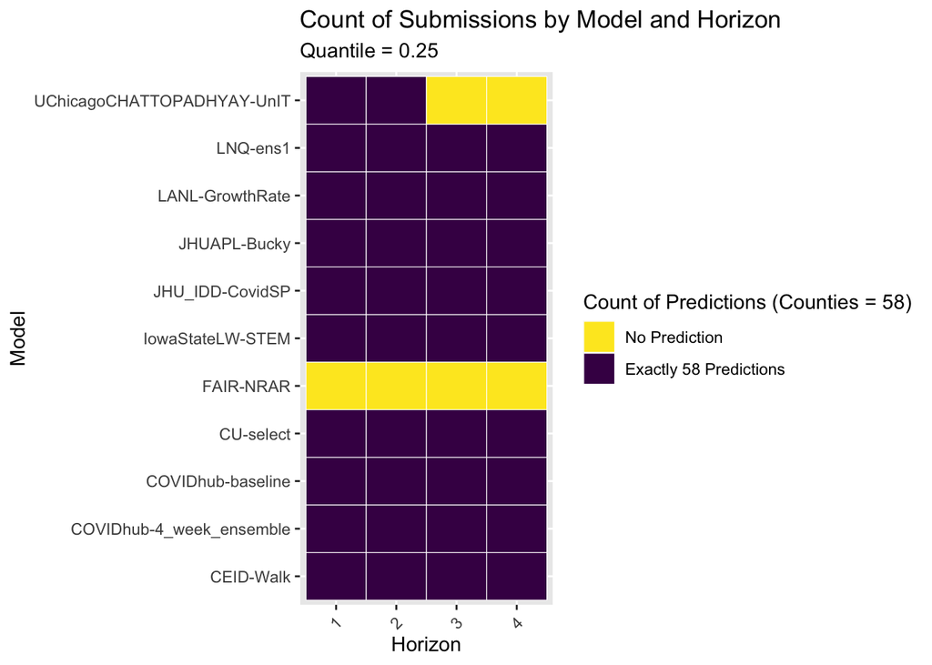

#### 10%

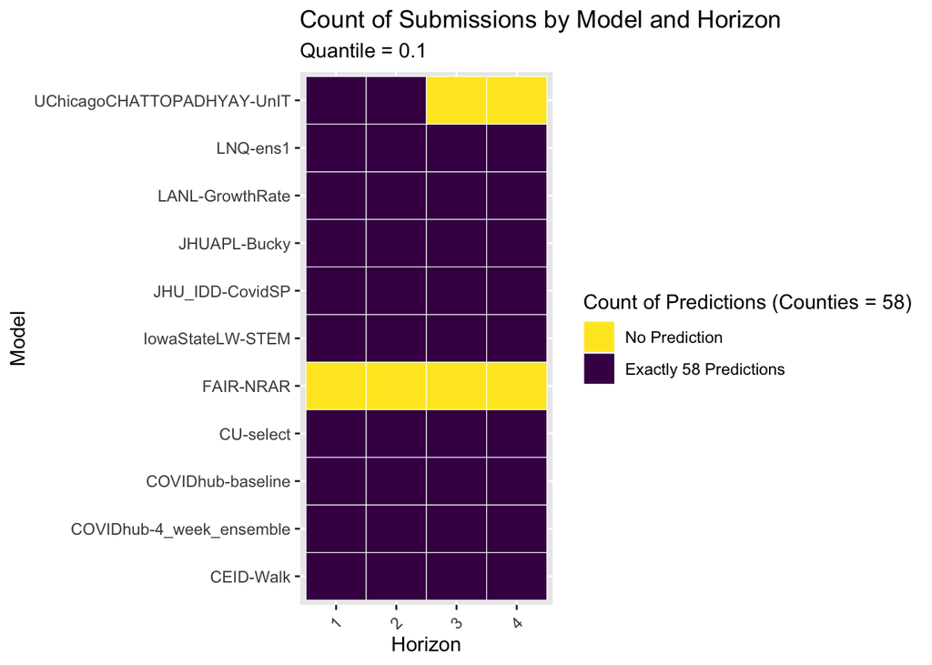

#### 2.5%

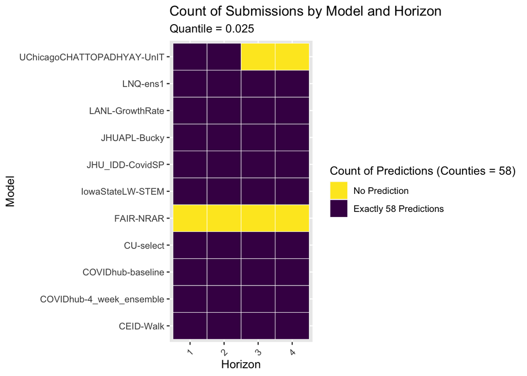

### November 21st, 2020

#### 50%

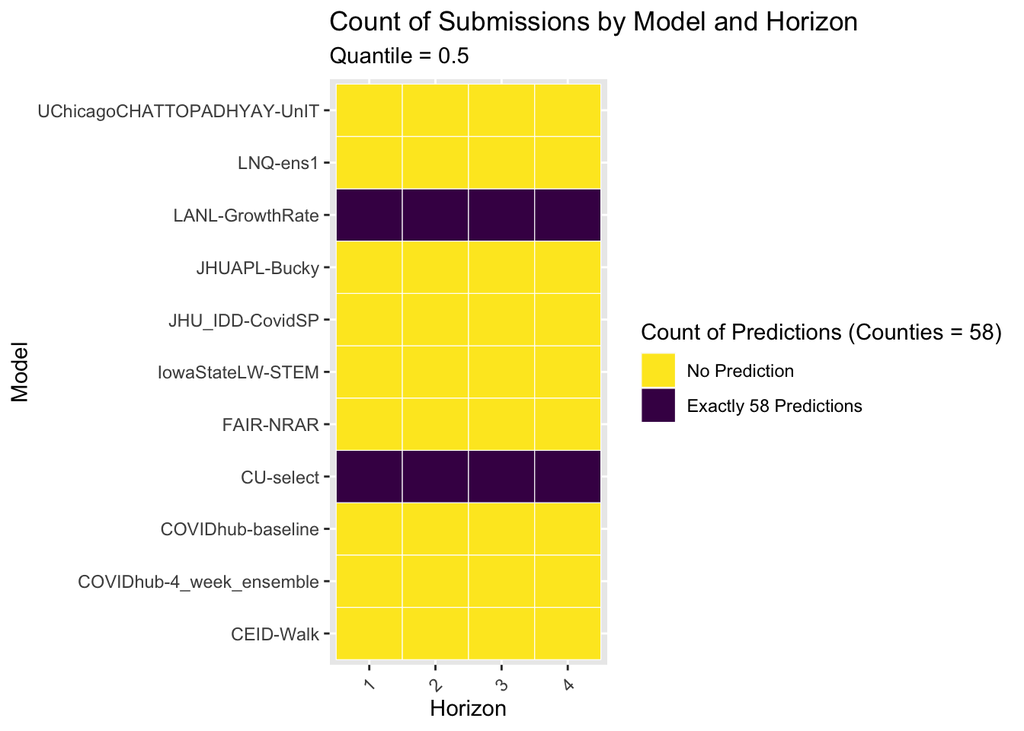

#### 25%

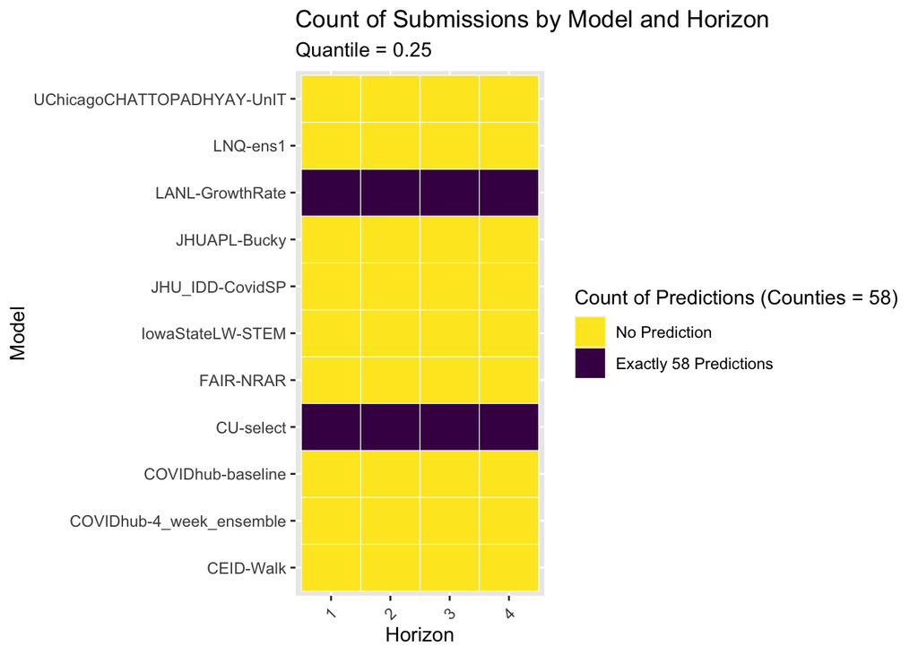

#### 10%

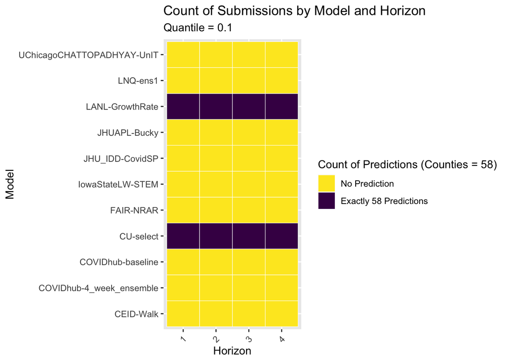

#### 2.5%

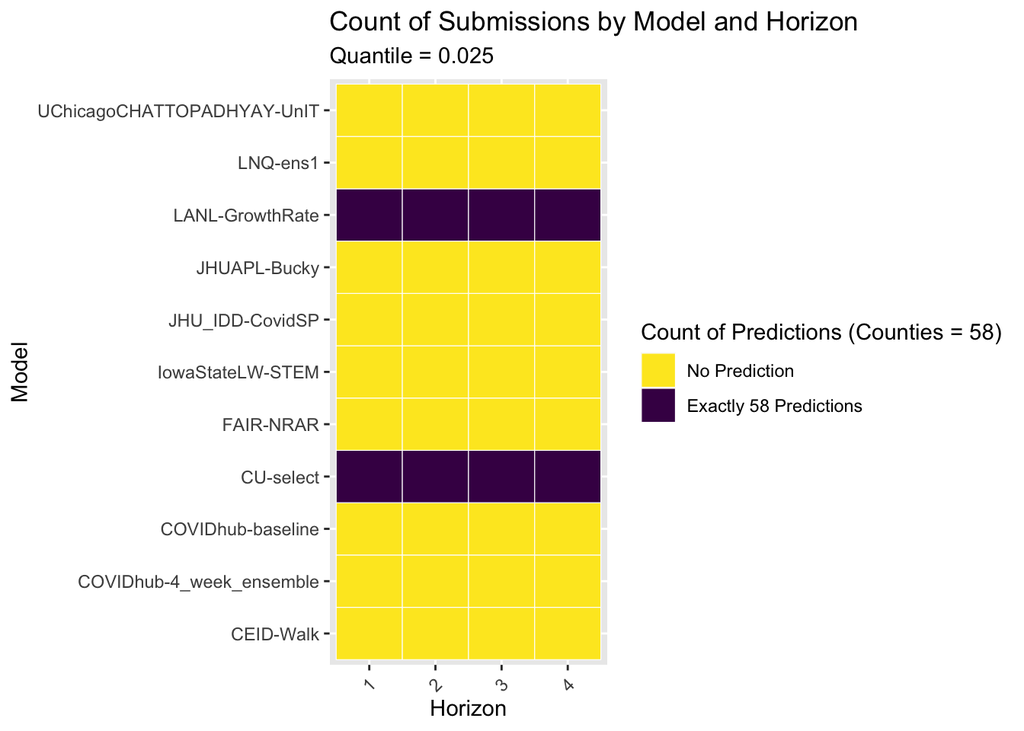

#### 25%

#### 10%

#### 2.5%

### January 1st, 2022

#### 50%

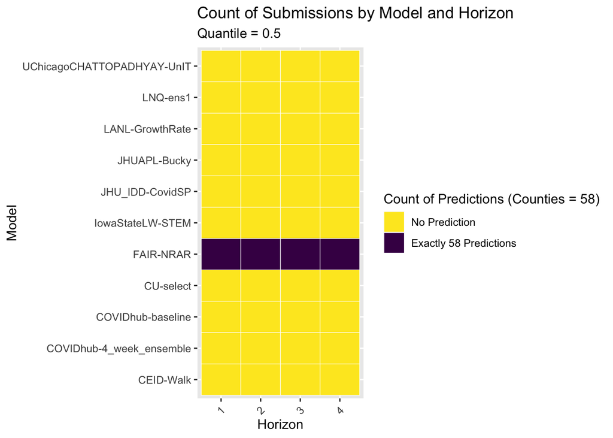

#### 25%

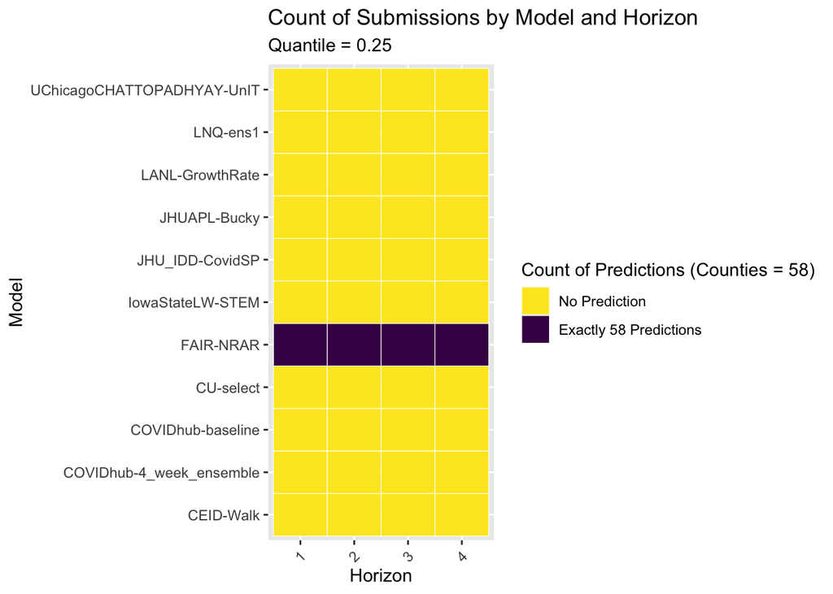

#### 10%

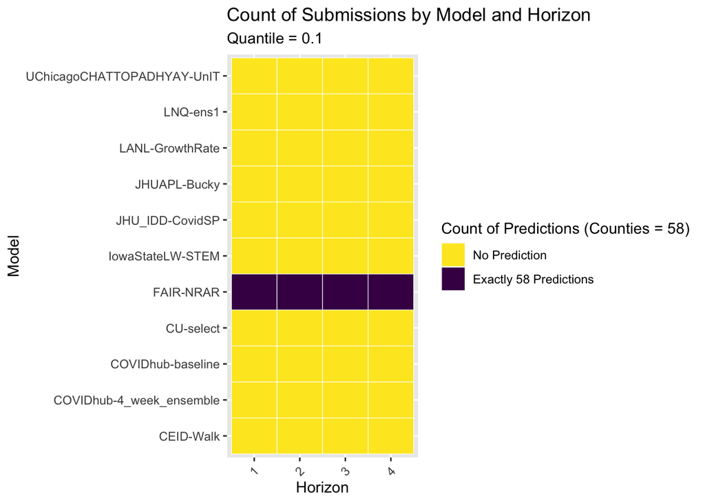

#### 2.5%

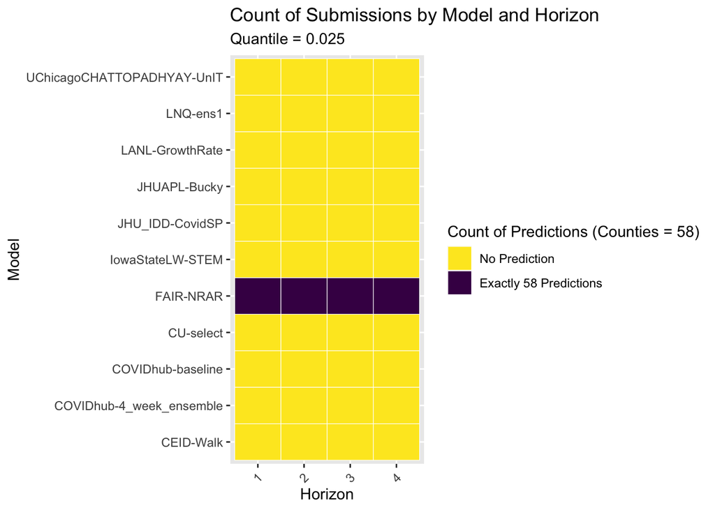

## Per-Capita Estimate: California Population Data

As a control model, allocation score was run on a per-capita allocation. In this approach, allocation ignores all epidemiologic and related data, allocating purely based on each county’s population. This allocation, we should note, stays constant throughout the period of interest.

California population data were sourced via the CA Department of Finance ([link here](https://dof.ca.gov/forecasting/demographics/estimates/)) - we used the 2020-2025 county level estimates.

## Resources to Allocate

# Allocation Score

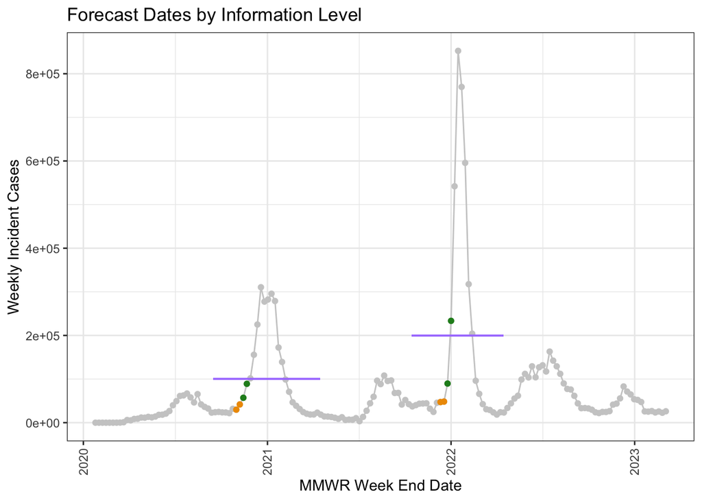

For each date, the selected models were run for weeks 1-4. Allocation scores were determined.

## Location-wise Allocation Over Time

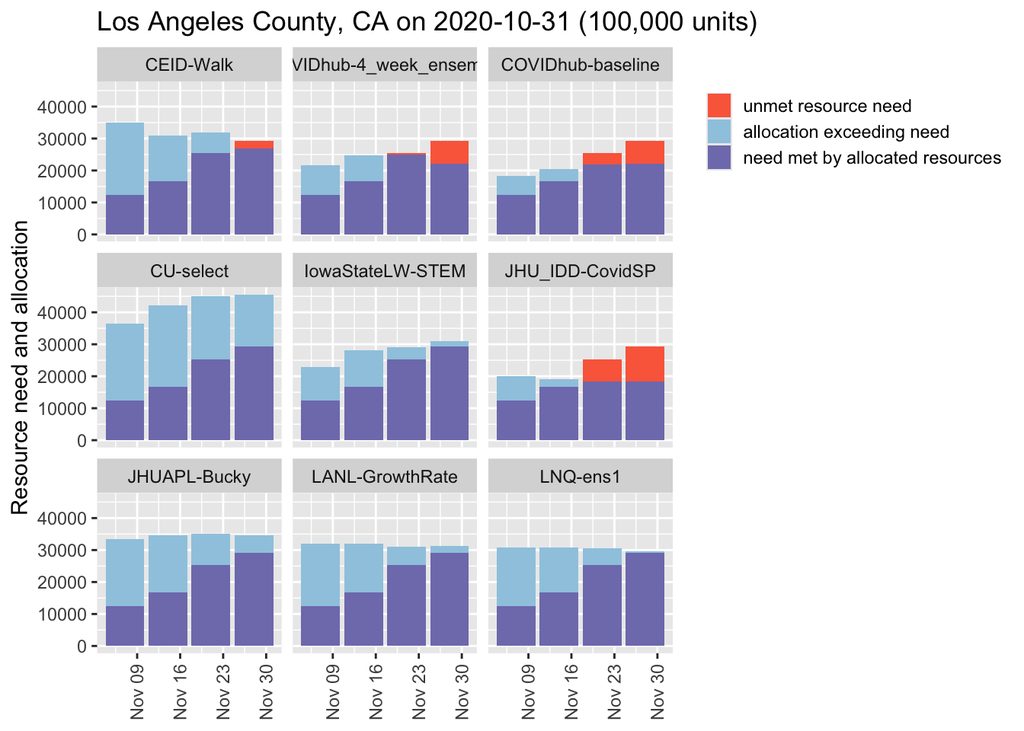

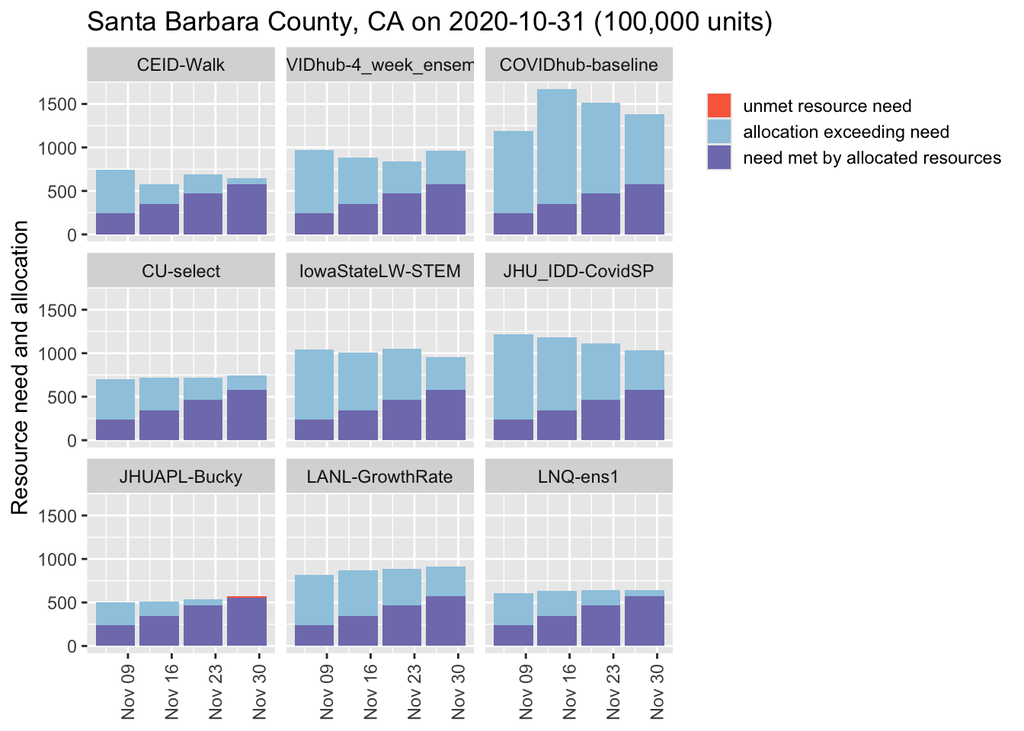

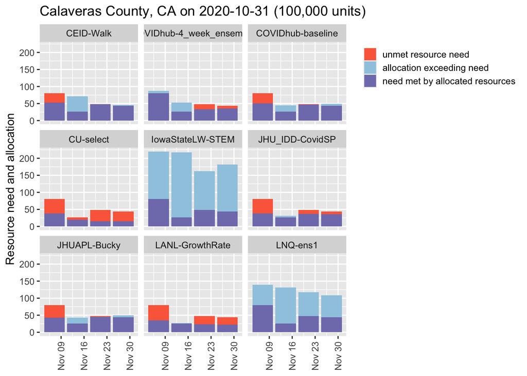

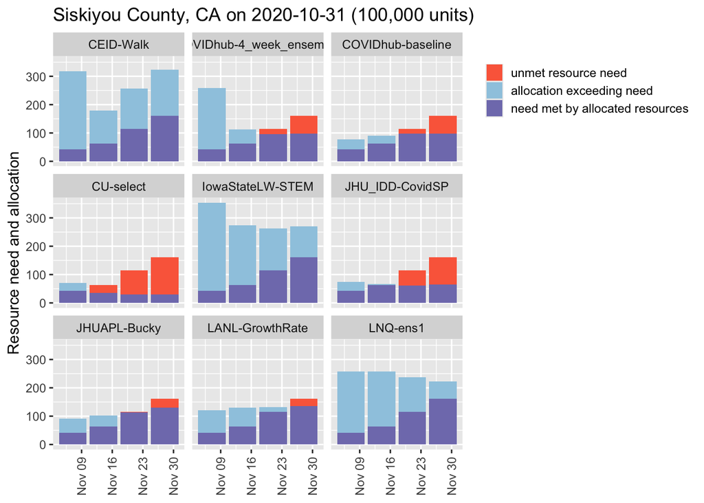

## October 31st, 2020

### 1 week

2020-10-31: Model scoring for the 1 week horizon (2020-11-07). Allocations conducted with a resource constraint of 100,000 units.

| model | alloscore | allo_rank | mwis | mwis_rank |
| --- | --- | --- | --- | --- |
| CEID-Walk | 0 | 1 | 143.8165 | 5 |
| COVIDhub-4_week_ensemble | 0 | 1 | 123.6307 | 2 |
| COVIDhub-baseline | 0 | 1 | 133.8762 | 4 |
| CU-select | 0 | 1 | 150.2107 | 6 |
| IowaStateLW-STEM | 0 | 1 | 161.2713 | 7 |
| JHU_IDD-CovidSP | 0 | 1 | 300.6061 | 9 |
| JHUAPL-Bucky | 0 | 1 | 180.3551 | 8 |
| LANL-GrowthRate | 0 | 1 | 131.4530 | 3 |
| LNQ-ens1 | 0 | 1 | 87.6612 | 1 |
| per-capita | 0 | 1 | NA | NA |

### 2 weeks

2020-10-31: Model scoring for the 2 week horizon (2020-11-14). Allocations conducted with a resource constraint of 100,000 units.

| model | alloscore | allo_rank | mwis | mwis_rank |
| --- | --- | --- | --- | --- |
| CEID-Walk | 0 | 1 | 347.4884 | 6 |
| COVIDhub-4_week_ensemble | 0 | 1 | 304.0783 | 4 |
| COVIDhub-baseline | 0 | 1 | 306.5050 | 5 |
| CU-select | 0 | 1 | 288.2038 | 2 |
| IowaStateLW-STEM | 0 | 1 | 476.8700 | 8 |
| JHU_IDD-CovidSP | 0 | 1 | 486.5170 | 9 |
| JHUAPL-Bucky | 0 | 1 | 442.2001 | 7 |
| LANL-GrowthRate | 0 | 1 | 294.6825 | 3 |
| LNQ-ens1 | 0 | 1 | 186.8766 | 1 |
| per-capita | 0 | 1 | NA | NA |

### 3 weeks

2020-10-31: Model scoring for the 3 week horizon (2020-11-21). Allocations conducted with a resource constraint of 100,000 units.

| model | alloscore | allo_rank | mwis | mwis_rank |
| --- | --- | --- | --- | --- |
| CEID-Walk | 0 | 1 | 859.5819 | 6 |
| COVIDhub-4_week_ensemble | 0 | 1 | 779.1739 | 4 |
| COVIDhub-baseline | 0 | 1 | 783.2634 | 5 |
| CU-select | 0 | 1 | 589.3872 | 2 |
| IowaStateLW-STEM | 0 | 1 | 1073.1929 | 9 |
| JHU_IDD-CovidSP | 0 | 1 | 954.6356 | 7 |
| JHUAPL-Bucky | 0 | 1 | 991.3041 | 8 |
| LANL-GrowthRate | 0 | 1 | 766.1280 | 3 |
| LNQ-ens1 | 0 | 1 | 521.5765 | 1 |
| per-capita | 0 | 1 | NA | NA |

### 4 weeks

2020-10-31: Model scoring for the 4 week horizon (2020-11-28). Allocations conducted with a resource constraint of 100,000 units.

| model | alloscore | allo_rank | mwis | mwis_rank |
| --- | --- | --- | --- | --- |
| per-capita | 0.0000 | 1 | NA | NA |
| COVIDhub-baseline | 465.7158 | 2 | 942.9784 | 4 |
| CEID-Walk | 514.9768 | 3 | 1041.9811 | 6 |
| COVIDhub-4_week_ensemble | 529.0307 | 4 | 957.6692 | 5 |
| JHU_IDD-CovidSP | 652.0146 | 5 | 1161.3064 | 7 |
| CU-select | 710.6021 | 6 | 716.0105 | 2 |
| JHUAPL-Bucky | 740.0191 | 7 | 1207.5407 | 8 |
| IowaStateLW-STEM | 798.6045 | 8 | 1327.3647 | 9 |
| LANL-GrowthRate | 839.4009 | 9 | 942.5146 | 3 |
| LNQ-ens1 | 1018.9689 | 10 | 620.6136 | 1 |

### Scores over time

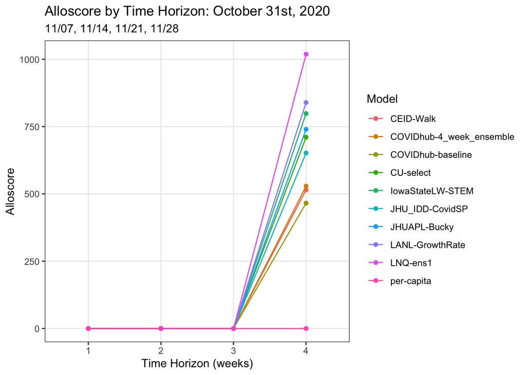

### Rankings over time

#### Alloscore

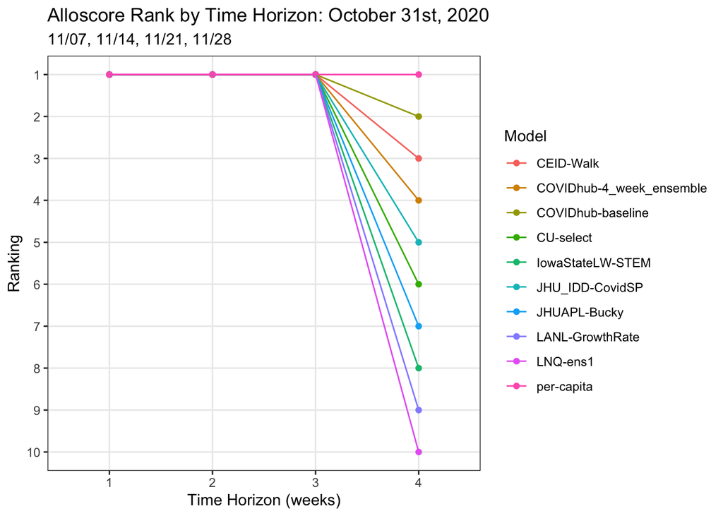

#### WIS

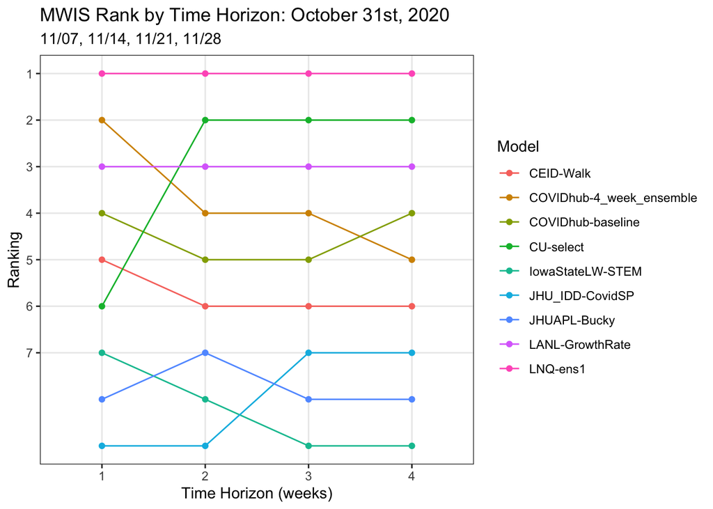

#### Kendall’s Tau a

##### 1 week

```
##
##  Kendall's rank correlation tau
##
## data:  summary1_100$alloscore and summary1_100$mwis
## T = NA, p-value = NA
## alternative hypothesis: true tau is not equal to 0
## sample estimates:
## tau
##  NA
```

##### 2 week

```
##
##  Kendall's rank correlation tau
##
## data:  summary2_100$alloscore and summary2_100$mwis
## T = NA, p-value = NA
## alternative hypothesis: true tau is not equal to 0
## sample estimates:
## tau
##  NA
```

##### 3 week

```
##
##  Kendall's rank correlation tau
##
## data:  summary3_100$alloscore and summary3_100$mwis
## T = NA, p-value = NA
## alternative hypothesis: true tau is not equal to 0
## sample estimates:
## tau
##  NA
```

##### 4 week

```
##
##  Kendall's rank correlation tau
##
## data:  summary4_100$alloscore and summary4_100$mwis
## T = 17, p-value = 0.9195
## alternative hypothesis: true tau is not equal to 0
## sample estimates:
##         tau
## -0.05555556
```

## November 7th, 2020

### 1 week

2020-11-07: Model scoring for the 1 week horizon (2020-11-14). Allocations conducted with a resource constraint of 100,000 units.

| model | alloscore | allo_rank | mwis | mwis_rank |
| --- | --- | --- | --- | --- |
| CEID-Walk | 0 | 1 | 241.3729 | 5 |
| COVIDhub-4_week_ensemble | 0 | 1 | 225.0681 | 4 |
| COVIDhub-baseline | 0 | 1 | 215.8115 | 3 |
| CU-select | 0 | 1 | 302.4595 | 7 |
| IowaStateLW-STEM | 0 | 1 | 390.8017 | 9 |
| JHUAPL-Bucky | 0 | 1 | 377.1951 | 8 |
| LANL-GrowthRate | 0 | 1 | 253.5938 | 6 |
| LNQ-ens1 | 0 | 1 | 142.4504 | 2 |
| per-capita | 0 | 1 | NA | NA |
| UChicagoCHATTOPADHYAY-UnIT | 0 | 1 | 119.3113 | 1 |

### 2 weeks

2020-11-07: Model scoring for the 2 week horizon (2020-11-21). Allocations conducted with a resource constraint of 100,000 units.

| model | alloscore | allo_rank | mwis | mwis_rank |
| --- | --- | --- | --- | --- |
| CEID-Walk | 0 | 1 | 730.2039 | 6 |
| COVIDhub-4_week_ensemble | 0 | 1 | 641.9052 | 3 |
| COVIDhub-baseline | 0 | 1 | 685.1103 | 5 |
| CU-select | 0 | 1 | 744.0262 | 7 |
| IowaStateLW-STEM | 0 | 1 | 1003.1113 | 9 |
| JHUAPL-Bucky | 0 | 1 | 927.4845 | 8 |
| LANL-GrowthRate | 0 | 1 | 678.7462 | 4 |
| LNQ-ens1 | 0 | 1 | 412.1156 | 2 |
| per-capita | 0 | 1 | NA | NA |
| UChicagoCHATTOPADHYAY-UnIT | 0 | 1 | 390.6304 | 1 |

### 3 weeks

2020-11-07: Model scoring for the 3 week horizon (2020-11-28). Allocations conducted with a resource constraint of 100,000 units.

| model | alloscore | allo_rank | mwis | mwis_rank |
| --- | --- | --- | --- | --- |
| per-capita | 340.5268 | 1 | NA | NA |
| COVIDhub-baseline | 388.5059 | 2 | 838.5747 | 4 |
| JHUAPL-Bucky | 452.3876 | 3 | 1140.4459 | 7 |
| CU-select | 456.1311 | 4 | 887.7858 | 5 |
| IowaStateLW-STEM | 549.8348 | 5 | 1265.0478 | 8 |
| LNQ-ens1 | 646.9272 | 6 | 463.5284 | 1 |
| CEID-Walk | 797.6202 | 7 | 907.6064 | 6 |
| COVIDhub-4_week_ensemble | 801.4574 | 8 | 721.7586 | 2 |
| LANL-GrowthRate | 837.8518 | 9 | 795.5456 | 3 |

### 4 weeks

2020-11-07: Model scoring for the 4 week horizon (2020-12-05). Allocations conducted with a resource constraint of 100,000 units.

| model | alloscore | allo_rank | mwis | mwis_rank |
| --- | --- | --- | --- | --- |
| per-capita | 340.5268 | 1 | NA | NA |
| JHUAPL-Bucky | 5668.3814 | 2 | 2071.236 | 7 |
| CEID-Walk | 6077.0845 | 3 | 1800.933 | 6 |
| COVIDhub-baseline | 7451.7073 | 4 | 1719.714 | 4 |
| COVIDhub-4_week_ensemble | 7763.4867 | 5 | 1541.187 | 2 |
| LANL-GrowthRate | 8880.9161 | 6 | 1601.677 | 3 |
| LNQ-ens1 | 9594.8410 | 7 | 1141.193 | 1 |
| IowaStateLW-STEM | 10853.4128 | 8 | 2235.952 | 8 |
| CU-select | 12098.1854 | 9 | 1792.534 | 5 |

### Scores over time

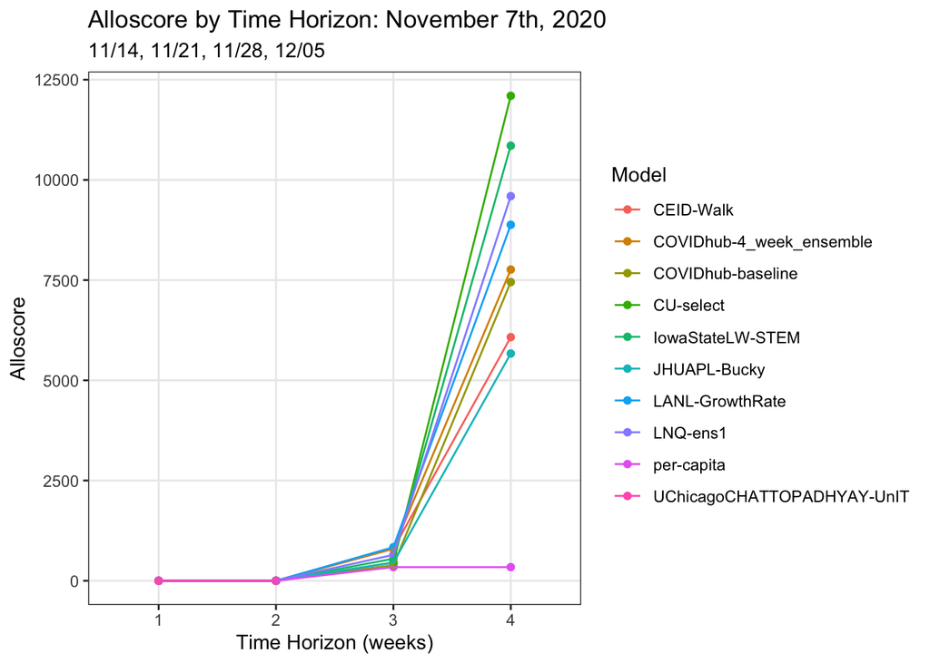

### Rankings over time

#### Alloscore

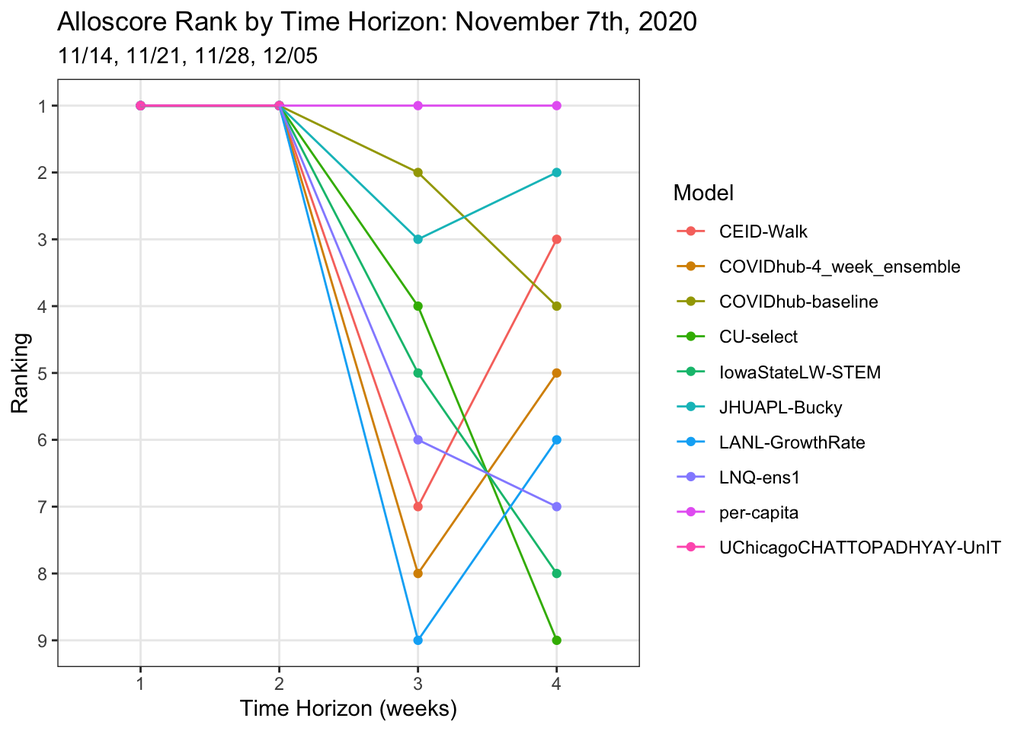

#### WIS

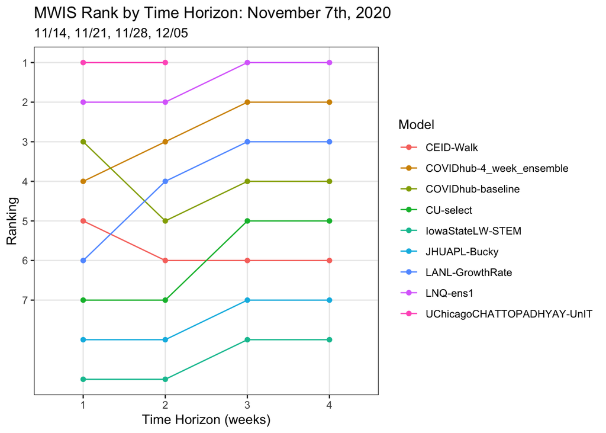

#### Kendall’s Tau a

##### 1 week

```
##
##  Kendall's rank correlation tau
##
## data:  summary1_100$alloscore and summary1_100$mwis
## T = NA, p-value = NA
## alternative hypothesis: true tau is not equal to 0
## sample estimates:
## tau
##  NA
```

##### 2 week

```
##
##  Kendall's rank correlation tau
##
## data:  summary2_100$alloscore and summary2_100$mwis
## T = NA, p-value = NA
## alternative hypothesis: true tau is not equal to 0
## sample estimates:
## tau
##  NA
```

##### 3 week

```
##
##  Kendall's rank correlation tau
##
## data:  summary3_100$alloscore and summary3_100$mwis
## T = 11, p-value = 0.5484
## alternative hypothesis: true tau is not equal to 0
## sample estimates:
##        tau
## -0.2142857
```

##### 4 week

```
##
##  Kendall's rank correlation tau
##
## data:  summary4_100$alloscore and summary4_100$mwis
## T = 11, p-value = 0.5484
## alternative hypothesis: true tau is not equal to 0
## sample estimates:
##        tau
## -0.2142857
```

## November 14th, 2020

### 1 week

2020-11-14: Model scoring for the 1 week horizon (2020-11-21). Allocations conducted with a resource constraint of 100,000 units.

| model | alloscore | allo_rank | mwis | mwis_rank |
| --- | --- | --- | --- | --- |
| CEID-Walk | 0 | 1 | 477.8383 | 7 |
| COVIDhub-4_week_ensemble | 0 | 1 | 343.3228 | 2 |
| COVIDhub-baseline | 0 | 1 | 471.4623 | 6 |
| CU-select | 0 | 1 | 529.1074 | 8 |
| IowaStateLW-STEM | 0 | 1 | 682.1350 | 10 |
| JHU_IDD-CovidSP | 0 | 1 | 543.0798 | 9 |
| JHUAPL-Bucky | 0 | 1 | 414.2532 | 4 |
| LANL-GrowthRate | 0 | 1 | 438.3830 | 5 |
| LNQ-ens1 | 0 | 1 | 196.9022 | 1 |
| per-capita | 0 | 1 | NA | NA |
| UChicagoCHATTOPADHYAY-UnIT | 0 | 1 | 357.0065 | 3 |

### 2 weeks

2020-11-14: Model scoring for the 2 week horizon (2020-11-28). Allocations conducted with a resource constraint of 100,000 units.

| model | alloscore | allo_rank | mwis | mwis_rank |
| --- | --- | --- | --- | --- |
| per-capita | 340.5268 | 1 | NA | NA |
| JHUAPL-Bucky | 395.8009 | 2 | 505.1467 | 5 |
| JHU_IDD-CovidSP | 475.6222 | 3 | 662.2878 | 9 |
| CEID-Walk | 529.9214 | 4 | 638.3313 | 8 |
| CU-select | 552.1527 | 5 | 548.3195 | 6 |
| COVIDhub-baseline | 552.3786 | 6 | 609.8762 | 7 |
| IowaStateLW-STEM | 554.0405 | 7 | 971.0799 | 10 |
| LANL-GrowthRate | 829.5683 | 8 | 493.7037 | 4 |
| UChicagoCHATTOPADHYAY-UnIT | 831.3916 | 9 | 347.0375 | 2 |
| LNQ-ens1 | 924.4927 | 10 | 213.1423 | 1 |
| COVIDhub-4_week_ensemble | 951.6970 | 11 | 388.1805 | 3 |

### 3 weeks

2020-11-14: Model scoring for the 3 week horizon (2020-12-05). Allocations conducted with a resource constraint of 100,000 units.

| model | alloscore | allo_rank | mwis | mwis_rank |
| --- | --- | --- | --- | --- |
| JHU_IDD-CovidSP | 7907.961 | 1 | 1196.5628 | 5 |
| COVIDhub-baseline | 8090.160 | 2 | 1478.8168 | 7 |
| CEID-Walk | 8147.258 | 3 | 1512.0031 | 8 |
| COVIDhub-4_week_ensemble | 8360.165 | 4 | 917.7915 | 3 |
| JHUAPL-Bucky | 8786.768 | 5 | 900.7071 | 2 |
| LANL-GrowthRate | 9180.504 | 6 | 1123.2984 | 4 |
| LNQ-ens1 | 10182.477 | 7 | 571.7595 | 1 |
| per-capita | 10693.343 | 8 | NA | NA |
| IowaStateLW-STEM | 10738.386 | 9 | 1955.1191 | 9 |
| CU-select | 11818.155 | 10 | 1331.2053 | 6 |

### 4 weeks

2020-11-14: Model scoring for the 4 week horizon (2020-12-12). Allocations conducted with a resource constraint of 100,000 units.

| model | alloscore | allo_rank | mwis | mwis_rank |
| --- | --- | --- | --- | --- |
| LNQ-ens1 | 10102.76 | 1 | 1292.084 | 1 |
| CEID-Walk | 10358.28 | 2 | 2665.876 | 8 |
| per-capita | 10693.34 | 3 | NA | NA |
| COVIDhub-4_week_ensemble | 11143.18 | 4 | 1809.090 | 3 |
| LANL-GrowthRate | 12257.75 | 5 | 2136.512 | 5 |
| JHU_IDD-CovidSP | 13799.20 | 6 | 1957.183 | 4 |
| COVIDhub-baseline | 14371.81 | 7 | 2603.743 | 7 |
| IowaStateLW-STEM | 14457.58 | 8 | 3196.635 | 9 |
| JHUAPL-Bucky | 15421.85 | 9 | 1502.668 | 2 |
| CU-select | 20410.43 | 10 | 2461.896 | 6 |

### Scores over time

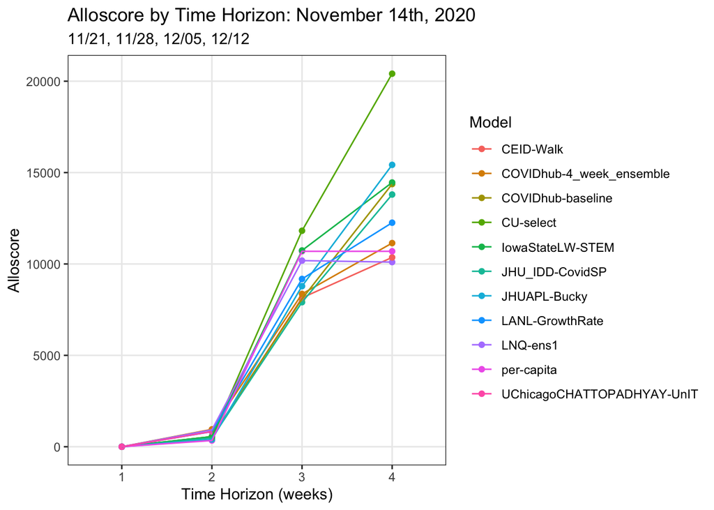

### Rankings over time

#### Alloscore

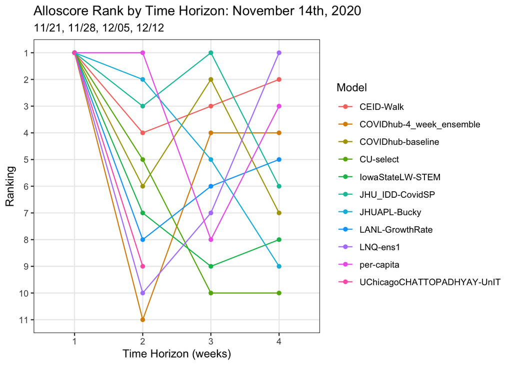

#### WIS

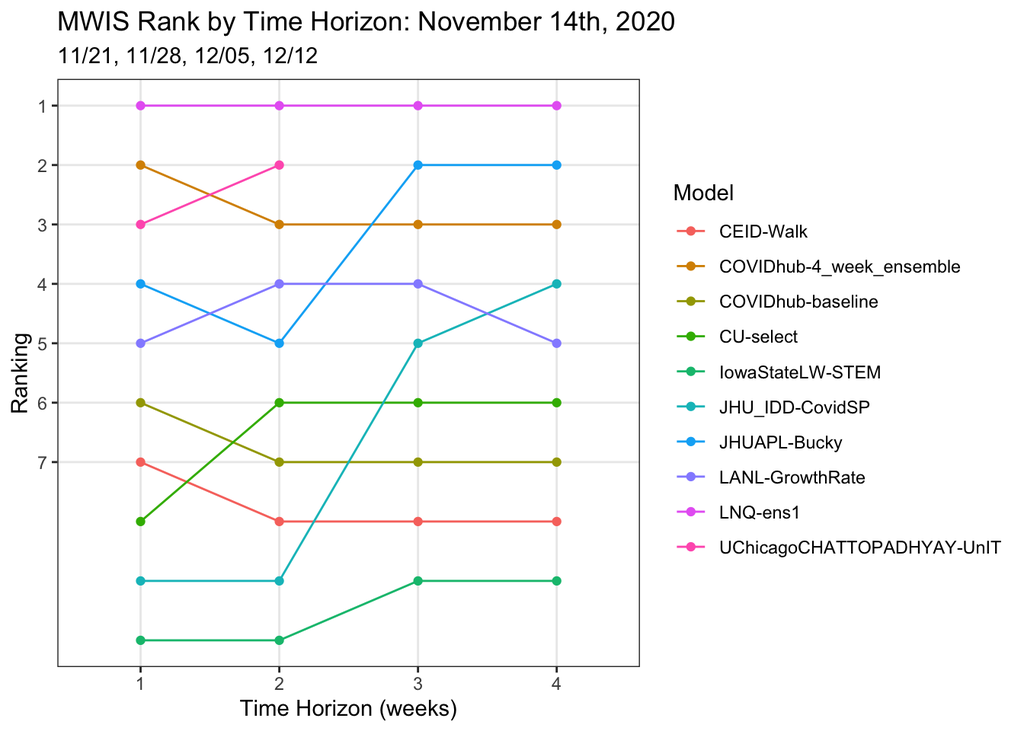

#### Kendall’s Tau a

##### 1 week

```
##
##  Kendall's rank correlation tau
##
## data:  summary1_100$alloscore and summary1_100$mwis
## T = NA, p-value = NA
## alternative hypothesis: true tau is not equal to 0
## sample estimates:
## tau
##  NA
```

##### 2 week

```
##
##  Kendall's rank correlation tau
##
## data:  summary2_100$alloscore and summary2_100$mwis
## T = 12, p-value = 0.07255
## alternative hypothesis: true tau is not equal to 0
## sample estimates:
##        tau
## -0.4666667
```

##### 3 week

```
##
##  Kendall's rank correlation tau
##
## data:  summary3_100$alloscore and summary3_100$mwis
## T = 17, p-value = 0.9195
## alternative hypothesis: true tau is not equal to 0
## sample estimates:
##         tau
## -0.05555556
```

##### 4 week

```
##
##  Kendall's rank correlation tau
##
## data:  summary4_100$alloscore and summary4_100$mwis
## T = 22, p-value = 0.4767
## alternative hypothesis: true tau is not equal to 0
## sample estimates:
##       tau
## 0.2222222
```

## November 21st, 2020

### 1 week

2020-11-21: Model scoring for the 1 week horizon (2020-11-28). Allocations conducted with a resource constraint of 100,000 units.

| model | alloscore | allo_rank | mwis | mwis_rank |
| --- | --- | --- | --- | --- |
| CU-select | 516.2515 | 1 | 246.7239 | 2 |
| LANL-GrowthRate | 877.8084 | 2 | 243.5756 | 1 |

### 2 weeks

2020-11-21: Model scoring for the 2 week horizon (2020-12-05). Allocations conducted with a resource constraint of 100,000 units.

| model | alloscore | allo_rank | mwis | mwis_rank |
| --- | --- | --- | --- | --- |
| LANL-GrowthRate | 8867.055 | 1 | 677.2654 | 2 |
| CU-select | 15053.761 | 2 | 589.5170 | 1 |

### 3 weeks

2020-11-21: Model scoring for the 3 week horizon (2020-12-12). Allocations conducted with a resource constraint of 100,000 units.

| model | alloscore | allo_rank | mwis | mwis_rank |
| --- | --- | --- | --- | --- |
| LANL-GrowthRate | 11409.04 | 1 | 1560.579 | 2 |
| CU-select | 21762.43 | 2 | 1055.136 | 1 |

### 4 weeks

2020-11-21: Model scoring for the 4 week horizon (2020-12-19). Allocations conducted with a resource constraint of 100,000 units.

| model | alloscore | allo_rank | mwis | mwis_rank |
| --- | --- | --- | --- | --- |
| LANL-GrowthRate | 11944.44 | 1 | 2937.296 | 2 |
| CU-select | 22008.56 | 2 | 1882.032 | 1 |

### Scores over time

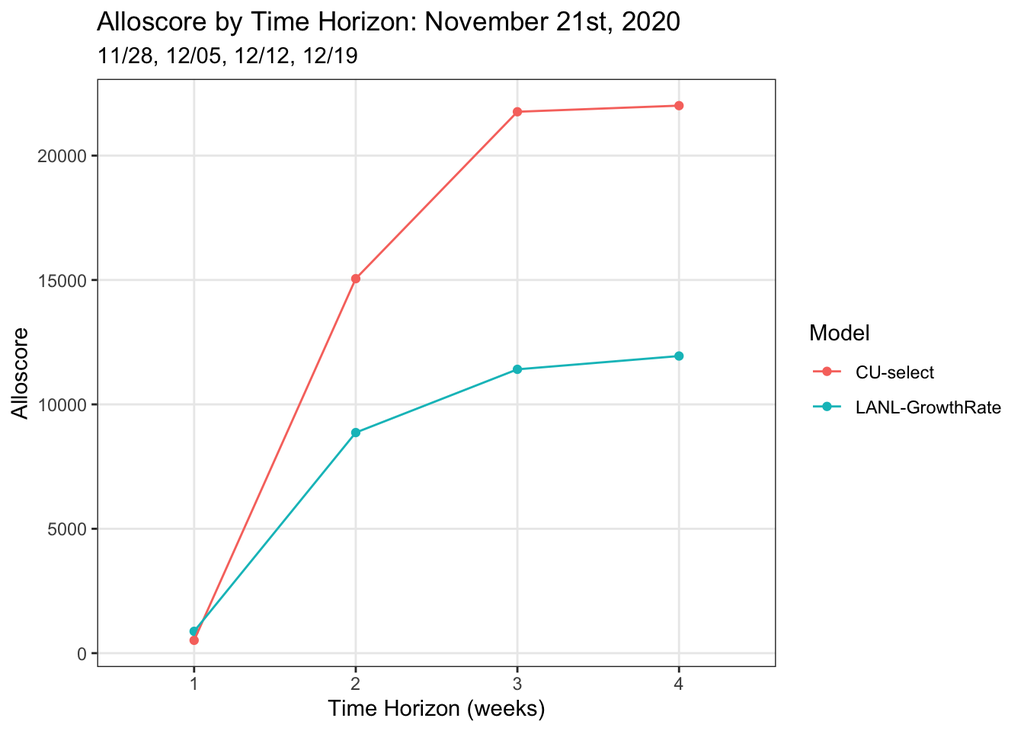

### Rankings over time

#### Alloscore

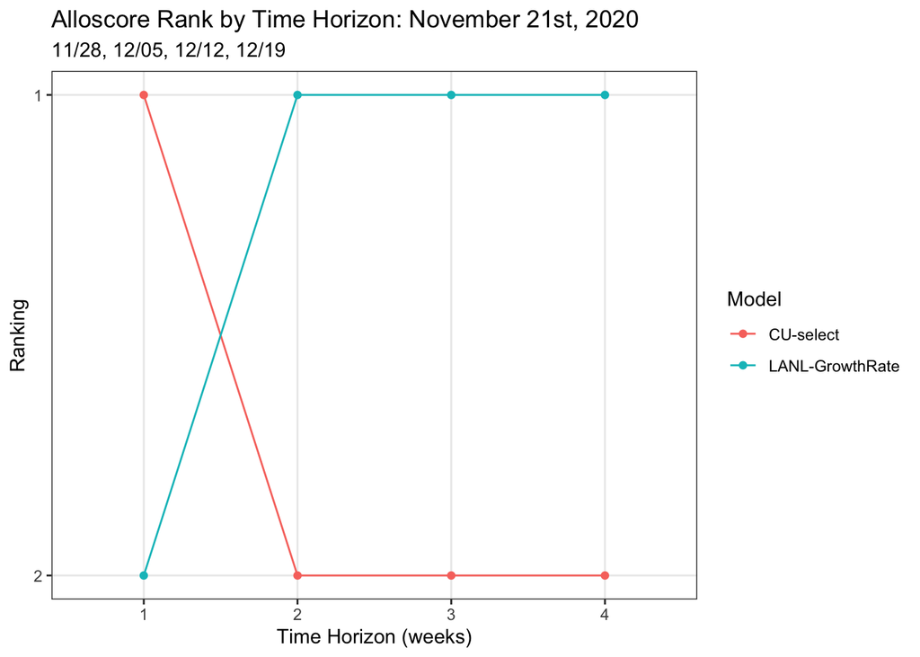

#### WIS

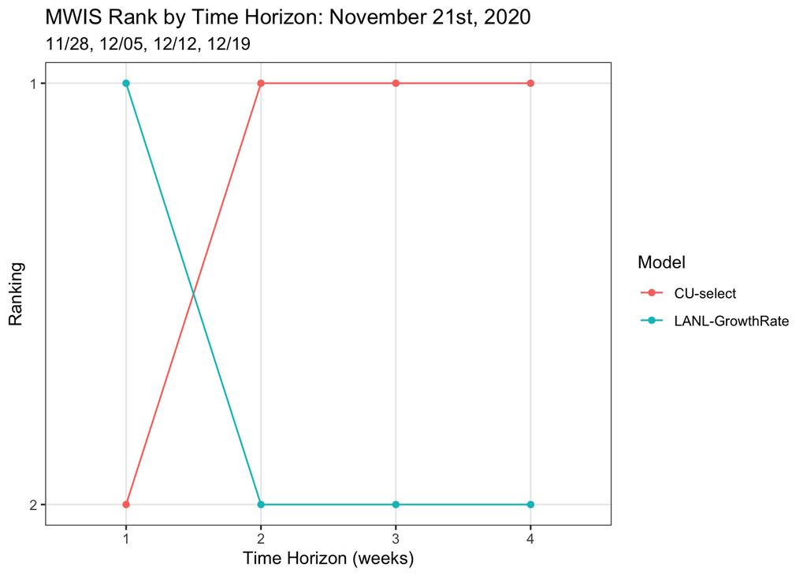

#### Kendall’s Tau a

##### 1 week

```
##
##  Kendall's rank correlation tau
##
## data:  summary1_100$alloscore and summary1_100$mwis
## T = 0, p-value = 1
## alternative hypothesis: true tau is not equal to 0
## sample estimates:
## tau
##  -1
```

##### 2 week

```
##
##  Kendall's rank correlation tau
##
## data:  summary2_100$alloscore and summary2_100$mwis
## T = 0, p-value = 1
## alternative hypothesis: true tau is not equal to 0
## sample estimates:
## tau
##  -1
```

##### 3 week

```
##
##  Kendall's rank correlation tau
##
## data:  summary3_100$alloscore and summary3_100$mwis
## T = 0, p-value = 1
## alternative hypothesis: true tau is not equal to 0
## sample estimates:
## tau
##  -1
```

##### 4 week

```
##
##  Kendall's rank correlation tau
##
## data:  summary4_100$alloscore and summary4_100$mwis
## T = 0, p-value = 1
## alternative hypothesis: true tau is not equal to 0
## sample estimates:
## tau
##  -1
```

## December 11th, 2021

### 1 week

2021-12-11: Model scoring for the 1 week horizon (2021-12-18). Allocations conducted with a resource constraint of 200,000 units.

| model | alloscore | allo_rank | mwis | mwis_rank |
| --- | --- | --- | --- | --- |
| COVIDhub-4_week_ensemble | 0 | 1 | 83.82882 | 1 |
| COVIDhub-baseline | 0 | 1 | 95.61847 | 2 |
| CU-select | 0 | 1 | 100.32463 | 3 |
| FAIR-NRAR | 0 | 1 | 152.03773 | 6 |
| JHUAPL-Bucky | 0 | 1 | 107.85957 | 4 |
| per-capita | 0 | 1 | NA | NA |
| UChicagoCHATTOPADHYAY-UnIT | 0 | 1 | 127.78533 | 5 |

### 2 weeks

2021-12-11: Model scoring for the 2 week horizon (2021-12-25). Allocations conducted with a resource constraint of 200,000 units.

| model | alloscore | allo_rank | mwis | mwis_rank |
| --- | --- | --- | --- | --- |
| COVIDhub-4_week_ensemble | 0 | 1 | 474.2676 | 3 |
| COVIDhub-baseline | 0 | 1 | 498.9909 | 4 |
| CU-select | 0 | 1 | 421.2115 | 2 |
| FAIR-NRAR | 0 | 1 | 502.0122 | 5 |
| JHUAPL-Bucky | 0 | 1 | 305.3949 | 1 |
| per-capita | 0 | 1 | NA | NA |
| UChicagoCHATTOPADHYAY-UnIT | 0 | 1 | 755.2652 | 6 |

### 3 weeks

2021-12-11: Model scoring for the 3 week horizon (2022-01-01). Allocations conducted with a resource constraint of 200,000 units.

| model | alloscore | allo_rank | mwis | mwis_rank |
| --- | --- | --- | --- | --- |
| FAIR-NRAR | 7916.234 | 1 | 2657.881 | 5 |
| COVIDhub-baseline | 9296.581 | 2 | 2652.446 | 4 |
| per-capita | 11175.244 | 3 | NA | NA |
| CU-select | 11985.119 | 4 | 2476.182 | 2 |
| JHUAPL-Bucky | 12420.848 | 5 | 1470.841 | 1 |
| COVIDhub-4_week_ensemble | 13901.726 | 6 | 2606.029 | 3 |

### 4 weeks

2021-12-11: Model scoring for the 4 week horizon (2022-01-08). Allocations conducted with a resource constraint of 200,000 units.

| model | alloscore | allo_rank | mwis | mwis_rank |
| --- | --- | --- | --- | --- |
| per-capita | 11175.24 | 1 | NA | NA |
| COVIDhub-4_week_ensemble | 36567.19 | 2 | 7503.749 | 2 |
| JHUAPL-Bucky | 38703.68 | 3 | 5091.995 | 1 |
| CU-select | 40760.73 | 4 | 7553.097 | 3 |
| COVIDhub-baseline | 41607.61 | 5 | 7726.125 | 4 |
| FAIR-NRAR | 46790.04 | 6 | 7785.509 | 5 |

### Scores over time

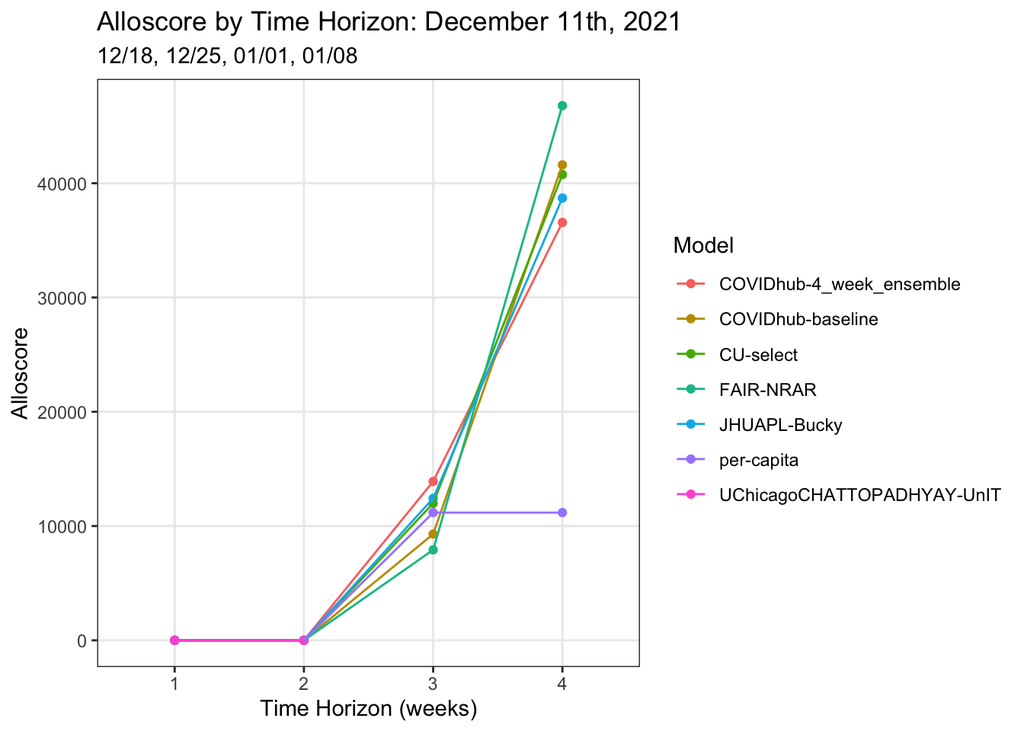

### Rankings over time

#### Alloscore

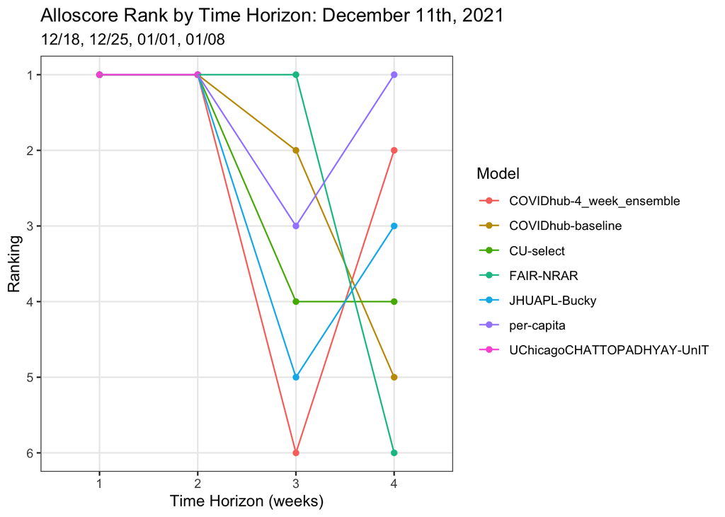

#### WIS

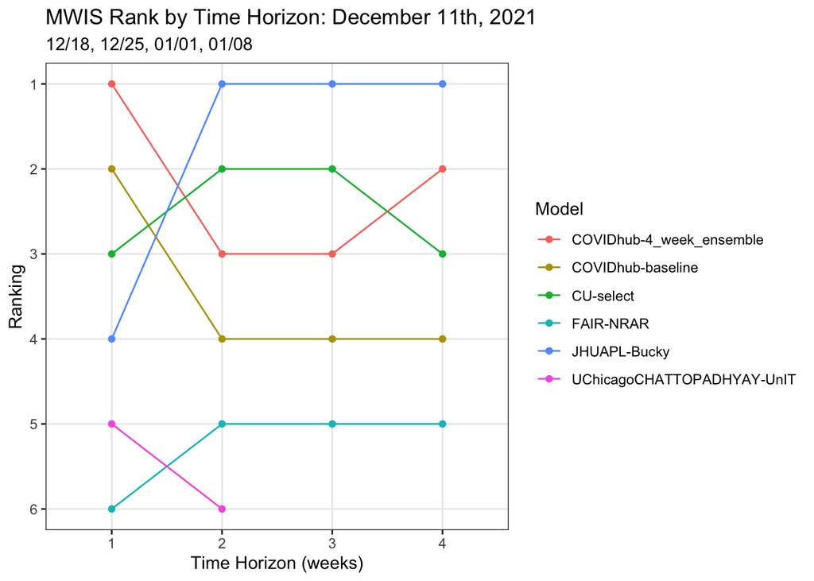

#### Kendall’s Tau a

##### 1 week

```
##
##  Kendall's rank correlation tau
##
## data:  summary1_200$alloscore and summary1_200$mwis
## T = NA, p-value = NA
## alternative hypothesis: true tau is not equal to 0
## sample estimates:
## tau
##  NA
```

##### 2 week

```
##
##  Kendall's rank correlation tau
##
## data:  summary2_200$alloscore and summary2_200$mwis
## T = NA, p-value = NA
## alternative hypothesis: true tau is not equal to 0
## sample estimates:
## tau
##  NA
```

##### 3 week

```
##
##  Kendall's rank correlation tau
##
## data:  summary3_200$alloscore and summary3_200$mwis
## T = 2, p-value = 0.2333
## alternative hypothesis: true tau is not equal to 0
## sample estimates:
##  tau
## -0.6
```

##### 4 week

```
##
##  Kendall's rank correlation tau
##
## data:  summary4_200$alloscore and summary4_200$mwis
## T = 9, p-value = 0.08333
## alternative hypothesis: true tau is not equal to 0
## sample estimates:
## tau
## 0.8
```